# Exploratory Data Analysis

## Week 1

### 1. Exploratory Graphs

#### Annual average PM2.5 averaged over the period 2008 - 2010

```r
download.file(url = "https://raw.githubusercontent.com/jtleek/modules/master/04_ExploratoryAnalysis/exploratoryGraphs/data/avgpm25.csv",
              destfile = "./Data/avgpm25.csv",
              method = "curl")
```

```r
pollution <- read.csv("./Data/avgpm25.csv",
                      colClasses = c("numeric", "character",
                                     "factor", "numeric", "numeric"))
head(pollution)
```

|  | pm25 | fips | region | longitude | latitude |
| --- | --- | --- | --- | --- | --- |
| 1 | 9.771185 | 01003 | east | -87.74826 | 30.59278 |
| 2 | 9.993817 | 01027 | east | -85.84286 | 33.26581 |
| 3 | 10.688618 | 01033 | east | -87.72596 | 34.73148 |
| 4 | 11.337424 | 01049 | east | -85.79892 | 34.45913 |
| 5 | 12.119764 | 01055 | east | -86.03212 | 34.01860 |
| 6 | 10.827805 | 01069 | east | -85.35039 | 31.18973 |

#### Research question

> Do any counties exceed the EPA standard of $12\mu g/m_{3}$?

#### Simple summaries

```r
summary(pollution$pm25)
```

```
   Min. 1st Qu.  Median    Mean 3rd Qu.    Max.
  3.383   8.549  10.047   9.836  11.356  18.441
```

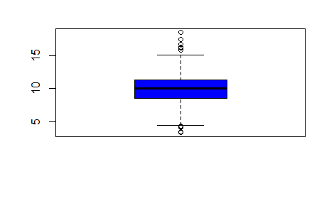

```r
boxplot(pollution$pm25, col = "blue")
```

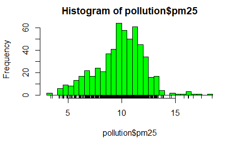

```r
hist(pollution$pm25, col = "green", breaks = 50)
rug(pollution$pm25)
```

#### Overlaying features

We can overlay features, for example a threshold (in this case the EPA standard), or the median.

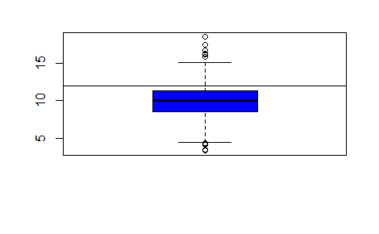

```r
boxplot(pollution$pm25, col = "blue")
abline(h = 12)
```

```r
hist(pollution$pm25, col  = "green")
abline(v = 12, lwd = 2)
```

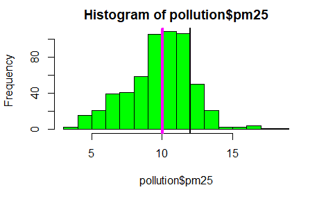

```r
abline(v = median(pollution$pm25), col  = "magenta", lwd = 4)
```

#### Plotting categorical data

We can use `barplot` to plot categorical data, for example counties per region.

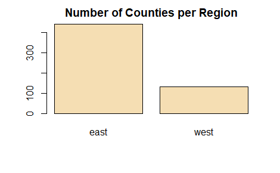

```r
barplot(table(pollution$region), col = "wheat",
        main = "Number of Counties per Region")
```

#### Other simple summaries

Two dimensions:

- Multiple/overlayed 1D plots
- Scatterplots
- Smoothed scatterplots

More than two dimensions:

- Multiple/overlayed 2D plots; coplots
- Using colour, size and shape to add dimensions
- Spinning plots
- Actual 3D plots (not that useful)

#### Multiple boxplots

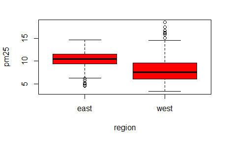

```r
boxplot(pm25 ~ region, data = pollution, col = "red")
```

#### Scatterplots

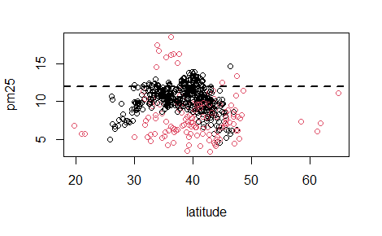

```r
with(pollution, plot(latitude, pm25, col = region))
abline(h = 12, lwd = 2, lty = 2)
```

**NB**: Here the colours represent eastern and western counties.

#### Multiple scatterplots

[figure not shown]

```r
par(mfrow = c(1,2), mar = c(5, 4, 2, 1))
with(subset(pollution, region = "west"), plot(latitude, pm25, main =  "West"))
with(subset(pollution, region = "east"), plot(latitude, pm25, main = "East"))
```

### 2. Plotting systems in R

#### base R

- Included with the base R installation.
- “Artist’s pallete” model: start with a blank canvas and build from there.
  - Usually start with a `plot` function.
  - Then use annotation functions to add or modify (`text`, `lines`, `points`, `axis`).
- Convenient, but cannot go back once plot has started.
- Difficult to “translate” to others, just a series of commands.
- Everything has to be set and controlled manually.

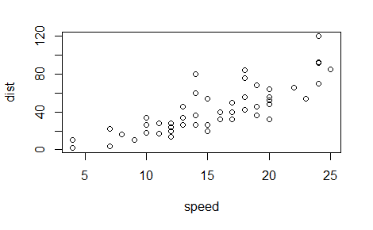

```r
library(datasets)
data(cars)
with(cars, plot(speed, dist))
```

#### lattice

- From the `lattice` package.
- Plots are created with a *single* function call (`xyplot`, `bwplot`, etc.)
- Most useful for conditioning plots or coplots, i.e. how y changes with x across levels of z.
- Things like margins and spacing are set automatically.
- Good for putting many, many plots on a screen.
- Sometimes awkward to specify in a single function call.
- Annotation in the plot is not possible after generated.
- Use of panel functions and subscripts is unwieldy.

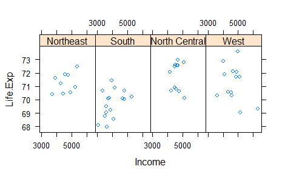

```r
library(lattice)
state <- data.frame(state.x77, region = state.region)
xyplot(Life.Exp ~ Income | region, data = state, layout = c(4,1))
```

#### ggplot2

- From the `ggplot2`/`tidyverse` package.
- Automatically deals with spacings, text, titles but also allows you to annotate by “adding” to a plot.
- Superficially similar to `lattice` but generally more intuitive.
- Default mode makes many choices for you, but can be customised.

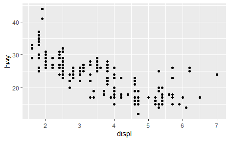

```r
library(ggplot2)
data(mpg)
qplot(displ, hwy, data = mpg)
```

### Base plotting in detail

Considerations when making a plot:

- Where will the plot be made? On screen or in a file?
- How will the plot be used?
  - For temporary viewing on screen?
  - For web presentation?
  - For a published paper?
  - For a presentation?
- How much data is going into the plot?
- Does it need to be dynamically resizable?
- What graphics system will you use?
  - **NB**: Plotting systems generally *cannot* be mixed.

#### Base graphics

- Most commonly used, very powerful for creating 2D graphics.
- Created in two *phases*:
  1. Initialising a new plot,
  2. Annotating an existing plot.
- Calling `plot(x, y)` or `hist()` will launch a *graphics device* and initalise a new plot on the device.
- If arguments are not of some special class, the *default* method for `plot` is called.
  - This function has *many* arguments, letting you set the title, axes labels, etc.
  - Parameters are documented in `?par`.

For example:

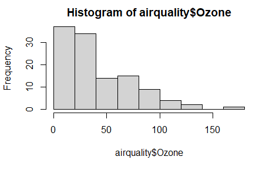

```r
library(datasets)
hist(airquality$Ozone) # Draw a new plot.
```

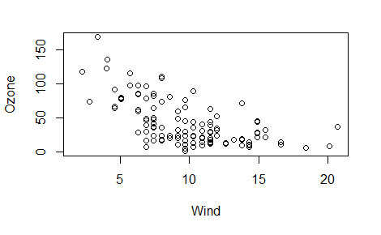

```r
with(airquality, plot(Wind, Ozone)) # Draw a new plot.
```

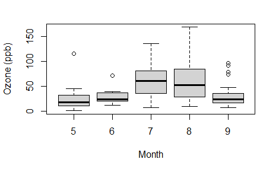

```r
boxplot(Ozone ~ Month, airquality, xlab = "Month", ylab = "Ozone (ppb)") # Draw a new plot.
```

#### Some important base parameters

- `pch`: plotting symbol (default = open circle)
- `lty`: line type (default = solid line)
- `lwd`: line width
- `col`: plotting colour, can be specified as a number string, hex code
  - **NB**: `colours()` function will give you a vector of colours by name
- `xlab`: character string for the x-axis label
- `ylab`: character string for the y-axis label

The `par()` function can specify *global* parameters that affect * all* plots in an R session. These can also be overridden when specified as arguments in specific plotting functions.

- `las`: the orientation of the axis labels
- `bg`: background colour
- `mar`: margin size
- `oma`: outer margin size (default = 0)
- `mfrow`: plots per row, column (fill matrix row-wise)
- `mfcol`: plots per row, column (fill matrix column-wise)

**NB**: You can find default values by using `par("")`, *e.g.*:

```r
par("bg")
```

```
[1] "white"
```

```r
par("mar")
```

[output not shown]

#### Base plotting functions

- `plot`: make a scatterplot or other type of plot
- `lines`: add lines to a plot, given a vector of x-y values, this function will connect the dots
- `points`: add points to a plot
- `text`: add text labels *within* a plot using specificed x-y coordinates
- `title`: adds annotations to axes labels, title, subtitle, outer margin
- `mtext`: add text labels *outside* a plot (inner or outer margins)
- `axis`: add axis ticks or labels

For example:

```r
with(airquality, plot(Wind, Ozone, main = "Ozone and Wind in New York City", type = "n"))
with(subset(airquality, Month == 5), points(Wind, Ozone, col = "blue"))
```

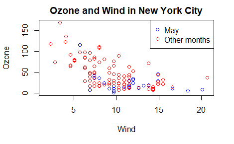

```r
with(subset(airquality, Month != 5), points(Wind, Ozone, col = "red"))
legend("topright", pch = 1, col = c("blue", "red"), legend = c("May", "Other months"))
```

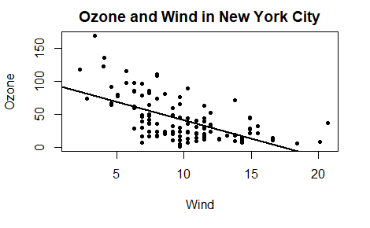

```r
with(airquality, plot(Wind, Ozone, main = "Ozone and Wind in New York City", pch = 20))
model <- lm(Ozone ~ Wind, airquality)
abline(model, lwd = 2)
```

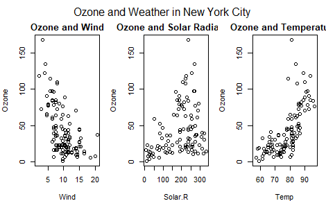

```r
par(mfrow = c(1, 3), mar = c(4, 4, 2, 1), oma = c(0, 0, 2, 0))
with(airquality, {
        plot(Wind, Ozone, main = "Ozone and Wind")
        plot(Solar.R, Ozone, main = "Ozone and Solar Radiation")
        plot(Temp, Ozone, main = "Ozone and Temperature")
        mtext("Ozone and Weather in New York City", outer = TRUE)
})
```